# Cross-Dataset Prediction of a Temozolomide-Response-Associated Biomarker in Glioblastoma

Author

Saidat Bello

# Question 1

## Study aim

This analysis addresses the following project question:

> Can a predictor of patient response be developed that works across different datasets?

This analysis addresses the project question indirectly by predicting a temozolomide-response-associated biomarker rather than observed patient response. A gene-expression classifier is developed in the TCGA glioblastoma cohort and externally evaluated in the CPTAC glioblastoma cohort. The outcome is MGMT promoter methylation, which is associated with temozolomide benefit but is not itself a direct measurement of treatment response.

The specific analysis question is:

> Can a gene-expression predictor of an MGMT methylation biomarker associated with temozolomide response transfer from TCGA to CPTAC?

The analysis prioritises features measured in both cohorts. This provides a practical compromise between model completeness and cross-dataset portability.

# 1. Analysis setup

# 2. Data sources and cohort preparation

TCGA was used as the model-development cohort and CPTAC was used as the independent external-validation cohort. Patient and sample files were used to confirm identifiers and retain one tumour sample per patient.

Clinical cohort summary before molecular-data matching

| cohort | patient_records | sample_records | unique_patients_after_selection |
| --- | --- | --- | --- |
| TCGA | 585 | 592 | 585 |
| CPTAC | 99 | 99 | 99 |

# 3. MGMT promoter methylation outcome

The supplied TCGA file is probe-level, whereas the supplied CPTAC file is gene-indexed and does not retain CpG probe identifiers. A comparable gene-level MGMT methylation score was therefore constructed in both cohorts by averaging all rows annotated to `MGMT` for each selected tumour sample. This is a study-specific molecular outcome and is not the clinical MGMT-STP27 classifier.

Only MGMT-annotated rows are extracted from each large methylation file, avoiding the need to load the complete matrices into memory.

## 3.1 Defining methylated and unmethylated groups

A two-group clustering model was fitted to the continuous, gene-level TCGA MGMT methylation scores. The midpoint between the two cluster centres was retained as the fixed classification threshold and applied unchanged to CPTAC.

TCGA-derived MGMT methylation classification threshold

| lower_cluster_centre | upper_cluster_centre | fixed_cutpoint |
| --- | --- | --- |
| 0.586 | 0.777 | 0.681 |

MGMT promoter methylation class distribution

| cohort | mgmt_status | n | percent |
| --- | --- | --- | --- |
| CPTAC | Methylated | 61 | 62.9 |
| CPTAC | Unmethylated | 36 | 37.1 |
| TCGA | Methylated | 118 | 84.9 |
| TCGA | Unmethylated | 21 | 15.1 |

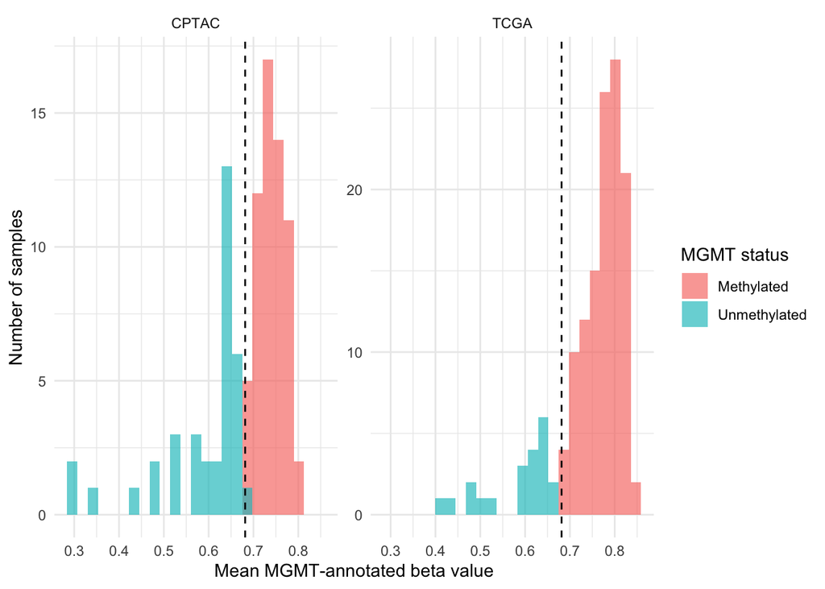

Distribution of the gene-level MGMT methylation score in TCGA and CPTAC.

# 4. Gene-expression preprocessing

The TCGA and CPTAC expression matrices use different quantification methods. Both matrices were therefore log-transformed. Only gene symbols present in both cohorts were retained.

Gene-expression feature availability across cohorts

| measure | number |
| --- | --- |
| TCGA genes | 20511 |
| CPTAC genes | 44950 |
| Genes present in both cohorts | 17593 |

## 4.1 Feature filtering

Genes were filtered using TCGA only. Genes with excessive missingness or near-zero variance were removed. The 500 most variable genes among those also measured in CPTAC were retained as candidate predictors.

Feature-filtering summary

| candidate_genes_available_in_both_cohorts | genes_entering_model_development |
| --- | --- |
| 17593 | 500 |

# 5. Construction of modelling datasets

Final matched cohorts used for model development and validation

| cohort | matched_patients | methylated | unmethylated |
| --- | --- | --- | --- |
| TCGA development | 51 | 43 | 8 |
| CPTAC validation | 97 | 61 | 36 |

# 6. Model development in TCGA

A LASSO logistic-regression model was used because it performs feature selection while limiting overfitting in high-dimensional molecular data.

The outcome was coded as:

- `1`: methylated
- `0`: unmethylated

Missing expression values were imputed using TCGA medians. TCGA means and standard deviations were then used to standardise both datasets, preventing information from CPTAC from influencing model development.

## 6.1 Internal cross-validation

Five-fold cross-validation was performed entirely within TCGA. Each held-out fold was predicted by a model that had not seen those patients. Within every outer fold, missing-value imputation and standardisation were estimated from that fold’s training patients and then applied to its held-out patients.

## 6.2 Final frozen model

The final model was fitted using all TCGA patients. The selected coefficients and TCGA preprocessing parameters were then frozen before CPTAC evaluation.

Non-zero genes selected by the final TCGA LASSO model

| feature | coefficient |
| --- | --- |
| TENM3 | 0.3965 |
| KLRC3 | -0.3541 |
| DDIT4L | 0.2284 |
| MEOX2 | 0.2016 |
| GABRA4 | 0.1949 |
| RHOD | 0.1261 |
| TMSB15A | -0.0908 |
| ZNF385B | 0.0876 |
| SMOC1 | -0.0848 |
| PCDHGB1 | -0.0149 |
| LINC00839 | -0.0145 |
| GLYATL2 | -0.0143 |
| GDA | 0.0014 |

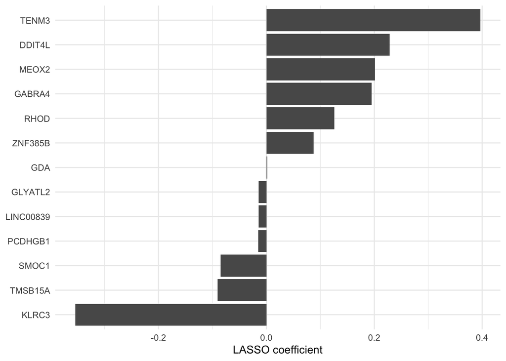

Genes retained in the final TCGA LASSO classifier.

# 7. Independent validation in CPTAC

The frozen TCGA model was applied to CPTAC without refitting coefficients, recalculating feature selection or using CPTAC outcome information.

Internal and external model performance

| cohort | auc | accuracy | sensitivity | specificity | positive_predictive_value | negative_predictive_value |
| --- | --- | --- | --- | --- | --- | --- |
| TCGA: five-fold cross-validation | 0.610 | 0.843 | 0.953 | 0.25 | 0.872 | 0.5 |
| CPTAC: external validation | 0.682 | 0.629 | 1.000 | 0.00 | 0.629 | NA |

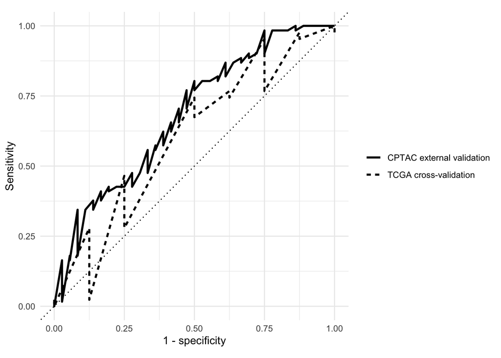

Receiver operating characteristic curves for TCGA internal cross-validation and CPTAC external validation.

```
TCGA cross-validation confusion matrix
```

```
              Observed
Predicted      Methylated Unmethylated
  Methylated           41            6
  Unmethylated          2            2
```

```
CPTAC external-validation confusion matrix
```

```
            Observed
Predicted    Methylated Unmethylated
  Methylated         61           36
```

# 8. Results summary

After matching methylation and expression data, the development cohort included 51 TCGA patients and the external-validation cohort included 97 CPTAC patients. The final LASSO model retained 13 non-zero gene-expression features. The internally cross-validated TCGA AUC was 0.61, while the independent CPTAC AUC was 0.682. At the prespecified probability threshold of 0.5, 97 of 97 CPTAC patients were classified as methylated, giving a specificity of 0.

# 9. Interpretation

The model demonstrated modest discrimination in the independent CPTAC cohort (AUC = 0.682), suggesting that some gene-expression signal associated with the derived MGMT methylation outcome transferred between datasets. However, at the prespecified probability threshold of 0.5, all CPTAC patients were classified as methylated. This produced 100% sensitivity but 0% specificity. The apparent accuracy of 62.9% therefore reflects the prevalence of the methylated class rather than effective binary classification.

These findings provide evidence of limited cross-dataset ranking ability, but not of a clinically useful or adequately calibrated binary predictor. Differences in expression quantification, methylation measurement, outcome construction, class balance and cohort composition may have contributed to the poor calibration.

The model deliberately used genes measured in both datasets rather than every feature available in TCGA. This may reduce maximum within-cohort performance, but it increases portability and directly addresses the project brief’s suggested compromise between data availability and data completeness.

# 10. Limitations

# 11. Conclusion

A gene-expression predictor developed in TCGA retained modest discriminatory information when applied to CPTAC, but it did not generalise successfully as a binary classifier at the prespecified threshold. The analysis therefore supports modest cross-dataset discrimination but demonstrates inadequate cross-dataset calibration.

Further harmonisation, calibration in a separate dataset and validation against a clinically established MGMT outcome would be required before the model could be considered practically or clinically useful. A threshold selected using CPTAC outcomes would require evaluation in a third independent cohort and is not presented here as validated performance.